# Using Interactive Dashboards for Public Communication

Kevin O'Brien

### Using Interactive Dashboards for Public Communication

- R Programming Language
- Open-Source Programming Language for Data Science

### Main Tools

- Flexdashboard
- Shiny

### Remark

I amended the format of the presentation to accommodate the live-streaming & recording audience, viewing on Youtube.

### Future Forests (Appsilon)

*https://connect.appsilon.com/future-forests/*

[figure not shown]

### Citizen Science: Dragonfly Survey

*https://biodiversityireland.ie/surveys/dragonfly-ireland/*

[figure not shown]

### About Me

### Current

- Resource Modeller (Forestry Statistician) with Coillte
- **Important** This talk is not connected with Coillte

### Some Previous Roles

- London Climate Change Coders
- Audience Research at Jameson Dublin International Film Festival
- Vice-chair for Social media and PR at JuliaCon and Why R? Foundation

### Audience

### Who is this talk for

- Importance of Public Perceptions
- Career young professionals in GIS with minimal exposure to Open Source GIS tools and programming languages (such as R)
- Those seeking to migrate from proprietary tools to open-source tools.
- Resource constraints
- Enabling Citizen Science

### Strategic Communication

### Public Outreach

- Interactive web-based tools to engage with public about scientific and environmental matters.
- Communicate that there can be a trade-off between competing goals.
- *Prof. David J. Mackay* - Chief Science Officer at UK *Dept of Energy and Climate Change (DECC)* used interactive dashboards 2013/2014 to better inform public discourse about Carbon emissions.
- Ahead of it's time, but Technology has only recently caught up.

### London Explorer

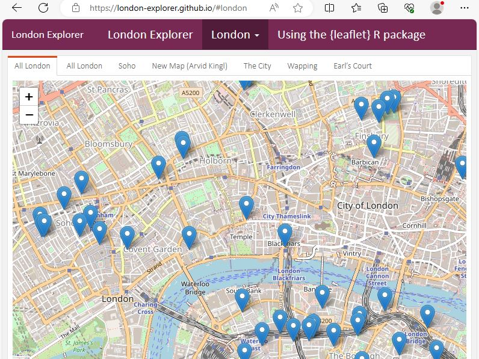

### Adding Colour Coding and Descriptions

- London Explorer - More Sophistication
- Ease of Collaboration with non-technical contributors

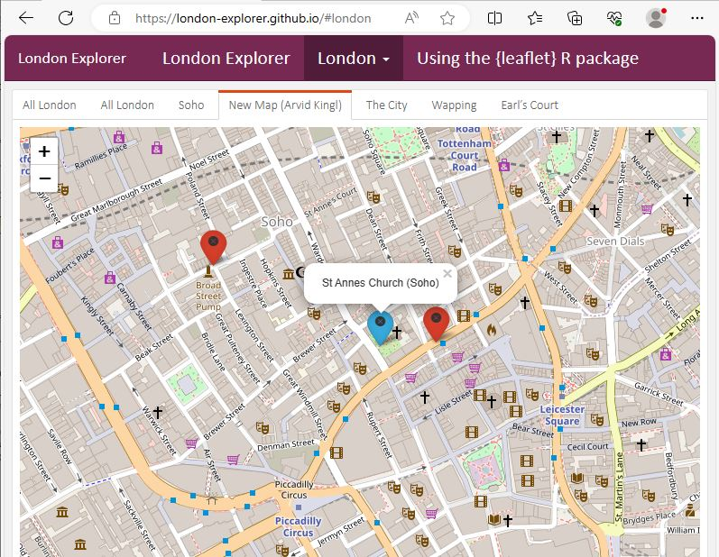

### London Explorer

### London Explorer

- Hobby Project - interesting places to visit in London
- Extremely simple construction using following R packages
  - `{flexdashboard}` - simple framework for interactive dashboards
  - `{leaflet}` - Interative GIS tool
  - `{tidyverse}` - a family of data processing tools
  - CSS : Cascading Style Sheets

### London Explorer

### Development and Deployment

- Written using RMarkdown, specifying layouts
- Quick to build and deploy
- Deployed as repository on a dedicated github organization
  - *London-Explorer.github.io*

### Collaboration

- Non-technical people contributed data through github repository pull-requests.

### Modularisation of R Markdown Code

Useful: `child =`

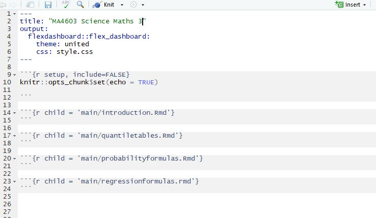

### Online Courses

### Coursera Course

- Data Visualization & Dashboarding with R Specialization

[figure not shown]

### Shiny Apps

### Interactive Dashboards

- Web-based, developed using R or Python
- More Technically Sophisticated than flexdashboards
- Account on ShinyApps.io
- Build for deployment
- Use {rsconnect} R package
- Use Log Files

### Shiny Apps

### Deployment

- Deployment from the Command Line

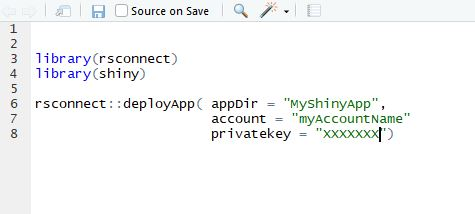

### Optimal Usage

- Preprocess the data objects before deployment and store them in an *.rdata file* in the Shiny App Folder

### Storing Objects in the Shiny App

#### Preprocessing the Data

```r
Project_A_1 <- runif(50)
Project_A_2 <- iris %>% head(20)
Project_A_3 <- mtcars %>% select(1:drat)
Project_A_4 <- "Kevin"

#  collect everything in the environment with the name "Project"
grep("Project",ls(),value=TRUE)
myObjectList <- grep("Project",ls(),value=TRUE)
```

### Stpring R Objects

#### Preprocessing the Data

```r
# Save these objects in an RDS file
saveRDS(  eval(str2expression(myObjectList)), "Project.rds")
```

#### Inside Shiny App

```r
# We are in the deployed shiny app now
# Project.rds is located in the app folder

readRDS("Project.rds")
```

### Evaluating Strings

#### Expressions

```r
expression = "5+5"

expression
```

```
[1] "5+5"
```

#### Evaluating Strings

```r
expression %>% str2expression() %>% eval()
```

```
[1] 10
```

### Expert-Beginner Problem

- Expert-Beginner Problem - unhelpful discourse
- Danger of Intellectual Comfort Zones
- “Tidyverse vs Base-R” - False Dichotomy
- Expansive Code Vocabulary is **Very Important**